# Project_1_COMP162

Jesus Lopez-Soto

2026-03-05

Introduction :

Data Set:

https://www.kaggle.com/datasets/bismasajjad/global-ai-job-market-and-salary-trends-2025

Data Set Description:

The dataset used in my analysis is titled “Global AI Job Market & Salary Trends 2025.” It contains information from about 15,000 job listings related to artificial intelligence, derived from more than 50 countries. Each observation in the dataset is representative of a single job posting.

These are the variables I worked with :

1. salary_usd – annual salary for the position, standardized to U.S. dollars
2. years_experience – number of years of experience required for the job
3. education_required – minimum level of education required for the job
4. company_size – categorized as small (<50 employees), medium (50–250 employees), or large (>250 employees)

Description of my motivation:

The main motivation for me to do this analysis was ultimately how the job market was behaving in the AI industry as a whole. However, another interest I had in this was to find out how people with a bachelors degree were doing in this relatively new industry. I figured a lot of people in a related educational field with me might find the results of my analysis to also be interesting.

Basic Summary Statistics of dataset( Variables I used ):

Salary :

Mean = 115,349

Median = 99,705

Min = 32,519

Max = 399,095

Experience :

Mean = 6.253

Median = 5

Min = 0

Max = 19

Education Required:

Associate

Bachelor

Master

PhD

Company Size:

Small (S) – fewer than 50 employees

Medium (M) – 50 to 250 employees

Large (L) – more than 250 employees

```r
#Read Data
AI_Data <- read.csv("ai_job_dataset.csv")

#Figure out number and rows
str(AI_Data)
```

```
## 'data.frame':    15000 obs. of  19 variables:
##  $ job_id                : chr  "AI00001" "AI00002" "AI00003" "AI00004" ...
##  $ job_title             : chr  "AI Research Scientist" "AI Software Engineer" "AI Specialist" "NLP Engineer" ...
##  $ salary_usd            : int  90376 61895 152626 80215 54624 123574 79670 70640 160710 102557 ...
##  $ salary_currency       : chr  "USD" "USD" "USD" "USD" ...
##  $ experience_level      : chr  "SE" "EN" "MI" "SE" ...
##  $ employment_type       : chr  "CT" "CT" "FL" "FL" ...
##  $ company_location      : chr  "China" "Canada" "Switzerland" "India" ...
##  $ company_size          : chr  "M" "M" "L" "M" ...
##  $ employee_residence    : chr  "China" "Ireland" "South Korea" "India" ...
##  $ remote_ratio          : int  50 100 0 50 100 50 0 0 0 0 ...
##  $ required_skills       : chr  "Tableau, PyTorch, Kubernetes, Linux, NLP" "Deep Learning, AWS, Mathematics, Python, Docker" "Kubernetes, Deep Learning, Java, Hadoop, NLP" "Scala, SQL, Linux, Python" ...
##  $ education_required    : chr  "Bachelor" "Master" "Associate" "PhD" ...
##  $ years_experience      : int  9 1 2 7 0 7 3 0 7 5 ...
##  $ industry              : chr  "Automotive" "Media" "Education" "Consulting" ...
##  $ posting_date          : chr  "2024-10-18" "2024-11-20" "2025-03-18" "2024-12-23" ...
##  $ application_deadline  : chr  "2024-11-07" "2025-01-11" "2025-04-07" "2025-02-24" ...
##  $ job_description_length: int  1076 1268 1974 1345 1989 819 1936 1286 551 2340 ...
##  $ benefits_score        : num  5.9 5.2 9.4 8.6 6.6 5.9 6.3 7.6 9.3 5.8 ...
##  $ company_name          : chr  "Smart Analytics" "TechCorp Inc" "Autonomous Tech" "Future Systems" ...
```

Number of Columns = 19 , Number or Rows = 15,000

```r
# Summarize
summary(AI_Data)
```

```
##     job_id           job_title           salary_usd     salary_currency
##  Length:15000       Length:15000       Min.   : 32519   Length:15000
##  Class :character   Class :character   1st Qu.: 70180   Class :character
##  Mode  :character   Mode  :character   Median : 99705   Mode  :character
##                                        Mean   :115349
##                                        3rd Qu.:146409
##                                        Max.   :399095
##  experience_level   employment_type    company_location   company_size
##  Length:15000       Length:15000       Length:15000       Length:15000
##  Class :character   Class :character   Class :character   Class :character
##  Mode  :character   Mode  :character   Mode  :character   Mode  :character
##
##
##
##  employee_residence  remote_ratio    required_skills    education_required
##  Length:15000       Min.   :  0.00   Length:15000       Length:15000
##  Class :character   1st Qu.:  0.00   Class :character   Class :character
##  Mode  :character   Median : 50.00   Mode  :character   Mode  :character
##                     Mean   : 49.48
##                     3rd Qu.:100.00
##                     Max.   :100.00
##  years_experience   industry         posting_date       application_deadline
##  Min.   : 0.000   Length:15000       Length:15000       Length:15000
##  1st Qu.: 2.000   Class :character   Class :character   Class :character
##  Median : 5.000   Mode  :character   Mode  :character   Mode  :character
##  Mean   : 6.253
##  3rd Qu.:10.000
##  Max.   :19.000
##  job_description_length benefits_score   company_name
##  Min.   : 500           Min.   : 5.000   Length:15000
##  1st Qu.:1004           1st Qu.: 6.200   Class :character
##  Median :1512           Median : 7.500   Mode  :character
##  Mean   :1503           Mean   : 7.504
##  3rd Qu.:2000           3rd Qu.: 8.800
##  Max.   :2499           Max.   :10.000
```

Variable Classification:

employment_type - Nominal

company_location - Nominal

employee_residence - Nominal

industry - Nominal

education_required - Ordinal

company_size - Ordinal

years_experience - Discrete

remote_ratio - Discrete

job_description_length - Discrete

benefits_score - Continuous

```r
# Cleaner Graphs
Clean_Data <- AI_Data

# Rename Variables & Sets
Clean_Data <- Clean_Data %>%

rename(`Education Level Required` = education_required) %>%

rename(`Years of Experience` = years_experience)
```

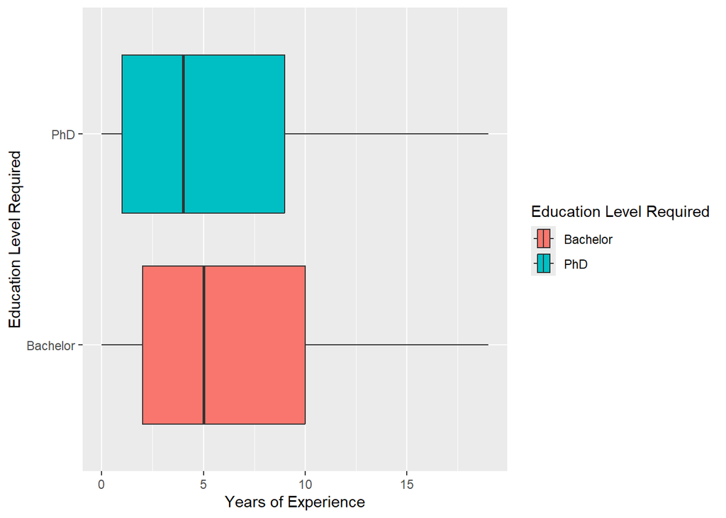

```r
# Plot of Quantitative and Categorical Variable

Clean_Data %>%

 filter(`Education Level Required` %in% c("Bachelor", "PhD")) %>%

ggplot(aes(`Years of Experience`,`Education Level Required`, fill = `Education Level Required` )) +

  geom_boxplot()
```

Interpretation:

The boxplot compares the distribution of required years of experience for AI jobs based on education level, in this case, it specifically shows positions requiring a Bachelor’s degree and those requiring a PhD.

The plot shows that the median and overall distribution of experience required for both groups are very similar.

```r
subset_data <- Clean_Data %>%

filter(`Education Level Required` %in% c("Bachelor", "PhD"))

t_test_result <- t.test(`Years of Experience` ~ `Education Level Required`, data = subset_data)

t_test_result
```

```
##
##  Welch Two Sample t-test
##
## data:  Years of Experience by Education Level Required
## t = 1.9529, df = 7464.8, p-value = 0.05087
## alternative hypothesis: true difference in means between group Bachelor and group PhD is not equal to 0
## 95 percent confidence interval:
##  -0.0009415251  0.5002627765
## sample estimates:
## mean in group Bachelor      mean in group PhD
##               6.304038               6.054377
```

Interpretation:

I used a Welch two-sample t-test to determine whether the average years of experience required differs between AI jobs requiring a Bachelor’s degree and those requiring a PhD.

The average required experience for Bachelor’s-level positions was approximately 6.30 years, while PhD-level positions averaged at 6.05 years. This shows that the averages are not too far apart between the two.

The test produced a p-value of 0.05087, and the 95% confidence interval (-0.00094, 0.50026) includes zero. This indicates that the difference in means is not statistically significant at the 0.05 level.

Therefore, based on this sample, there is not enough evidence to conclude that jobs requiring a PhD require more experience than those requiring a Bachelor’s degree in the broader AI job market.

These results suggest that AI jobs requiring a Bachelor’s degree and those requiring a PhD require approximately the same amount of experience, around six years on average, since the difference between the two groups was not statistically significant.

```r
# Rename Variables & Sets
Clean_Data <- Clean_Data %>%

mutate(company_size = recode(company_size, L = "Large")) %>%

mutate(company_size = recode(company_size, M = "Medium")) %>%

mutate(company_size = recode(company_size, S = "Small")) %>%

rename(`Salary USD` = salary_usd) %>%

rename(`Company Size` = company_size)
```

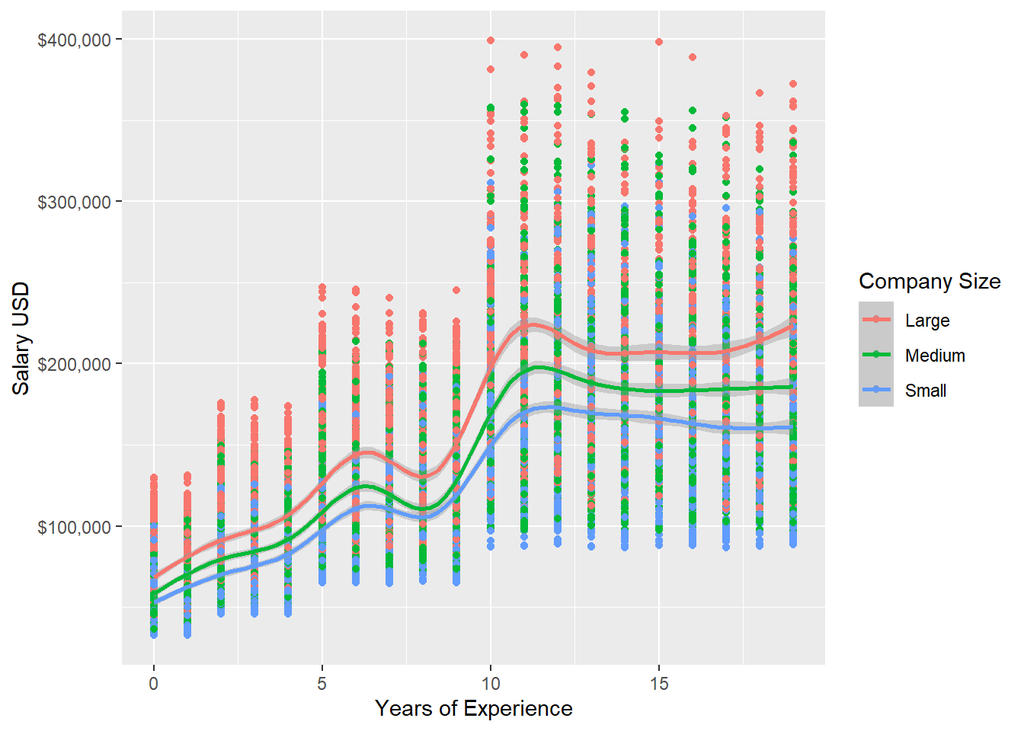

```r
#Plot 2

Clean_Data %>%

 ggplot(aes(`Years of Experience`, `Salary USD`, color = `Company Size`)) +

  geom_point() +

  geom_smooth() +

  scale_y_continuous(labels = scales::dollar)
```

Interpretation:

The scatterplot shows a general positive linear relationship between years of experience and salary, where the higher experience levels are generally associated with higher salaries.

However, there is some variability in the salaries for similar experience levels, suggesting that other outside factors may also be at play.

```r
# Linear Regression Model
model <- lm(`Salary USD` ~ `Years of Experience`, data = Clean_Data)
summary(model)
```

```
##
## Call:
## lm(formula = `Salary USD` ~ `Years of Experience`, data = Clean_Data)
##
## Residuals:
##     Min      1Q  Median      3Q     Max
## -129178  -24881   -5950   18845  253718
##
## Coefficients:
##                       Estimate Std. Error t value Pr(>|t|)
## (Intercept)           65233.53     500.78   130.3   <2e-16 ***
## `Years of Experience`  8014.37      59.92   133.8   <2e-16 ***
## ---
## Signif. codes:  0 '***' 0.001 '**' 0.01 '*' 0.05 '.' 0.1 ' ' 1
##
## Residual standard error: 40690 on 14998 degrees of freedom
## Multiple R-squared:  0.544,  Adjusted R-squared:  0.544
## F-statistic: 1.789e+04 on 1 and 14998 DF,  p-value: < 2.2e-16
```

Interpretation:

The slope of 8014.37 lets us predict that with each additional year of experience, an average salary increases by approximately $8,014.

The R-squared value is 0.544, meaning that about 54.4% of the variation in salaries can be explained by the years of experience alone.

The P-Value < 2.2e-16 , this means the relationship was found to be statistically significant. This indicates that it is extremely unlikely this relationship occurred by random chance.

Based on this linear regression model, we can suggest that the years of experience is a strong predictor of salary inside the AI job market.

```r
# Correlation
cor(Clean_Data$`Years of Experience`, Clean_Data$`Salary USD`)
```

```
## [1] 0.7375559
```

Interpretation:

This result indicates a strong positive correlation between the two variables. As the required years of experience increase, salaries seemingly tend to increase as well.

Because the correlation is relatively high, this suggests that experience may be strongly associated with higher salaries in these AI-related jobs.

Project Conclusion:

My analysis of the Global AI Job Market & Salary Trends dataset reveals several patterns in AI-related employment. First, both the correlation analysis and the linear regression model show a strong positive relationship between years of experience and salary.

The regression results suggest that each additional year of experience is associated with an average salary increase of approximately $8,000. This indicates that experience plays a major role in predicting your salary within the AI job market.

In contrast, the analysis comparing education levels suggests that jobs requiring a PhD do not necessarily require significantly more work experience than jobs requiring a Bachelor’s degree. The boxplot and t-test results show that both groups require approximately six years of experience on average, and the statistical test did not find a significant difference between them.

Overall, these findings suggest that while experience strongly influences salary, the amount of experience required for AI jobs may not vary substantially based on education level. This suggests that employers in the AI field may value practical experience and technical skills just as much as formal educational credentials when it comes to determining job requirements and compensation.